# Machine Learning: AllLife Bank Personal Loan Campaign

### Model Performance Improvement

### Pre-Pruning

#### HyperParameter Tuning using GridSearchCV

```python
# Let's find out the best values for the HyperParameter, so we can perform Pre-Pruning using best posssible values
from sklearn.model_selection import GridSearchCV

# Choose the type of classifier.
estimator = DecisionTreeClassifier(random_state=1)

# Grid of parameters to choose from
parameters = {'max_depth': np.arange(1,10),
              'min_samples_leaf': [1, 2, 5, 7, 10,15,20],
              'max_leaf_nodes' : [2, 3, 5, 10],
              'min_impurity_decrease': [0.001,0.01,0.1]
             }

# Type of scoring used to compare parameter combinations
acc_scorer = metrics.make_scorer(metrics.recall_score)

# Run the grid search
grid_obj = GridSearchCV(estimator, parameters, scoring=acc_scorer,cv=5)
grid_obj = grid_obj.fit(X_train, y_train)

# Set the clf to the best combination of parameters
estimator = grid_obj.best_estimator_

# Fit the best algorithm to the data.
estimator.fit(X_train, y_train)
```

```
DecisionTreeClassifier(max_depth=5, max_leaf_nodes=10,
                       min_impurity_decrease=0.001, min_samples_leaf=5,
                       random_state=1)
```

#### Best Values for HyperParameters

- max_depth = **5**
- max_leaf_nodes = **10**
- min_impurity_decrease = **0.001**
- min_samples_leaf = **5**
- random_state = **1**

```python
print(grid_obj.best_params_)
```

```
{'max_depth': 5, 'max_leaf_nodes': 10, 'min_impurity_decrease': 0.001, 'min_samples_leaf': 5}
```

### Build Pre-Pruned Decision Tree using the identified HyperParameters

```python
dTree_pre_pruned = DecisionTreeClassifier(criterion = 'gini', max_depth=5, max_leaf_nodes=10,
                                          min_impurity_decrease=0.001, min_samples_leaf=5, random_state=1)
dTree_pre_pruned.fit(X_train, y_train)
```

```
DecisionTreeClassifier(max_depth=5, max_leaf_nodes=10,
                       min_impurity_decrease=0.001, min_samples_leaf=5,
                       random_state=1)
```

### Score the Pre-Pruned Model

```python
print("Accuracy on training set : ",dTree_pre_pruned.score(X_train, y_train))
print("Accuracy on test set : ",dTree_pre_pruned.score(X_test, y_test))
```

```
Accuracy on training set :  0.9868571428571429
Accuracy on test set :  0.9746666666666667
```

### Check Pre-Pruned Model Performance

#### On Train Set

```python
# to check the classification metrics on train set
dTree_pre_pruned_perf_train = model_performance_classification(dTree_pre_pruned, X_train, y_train)
dTree_pre_pruned_perf_train
```

|  | Accuracy | Recall | Precision | F1 |
| --- | --- | --- | --- | --- |
| 0 | 0.986857 | 0.882175 | 0.976589 | 0.926984 |

#### On Test Set

```python
# to check the classification metrics on test set
dTree_pre_pruned_perf_test = model_performance_classification(dTree_pre_pruned, X_test, y_test)
dTree_pre_pruned_perf_test
```

|  | Accuracy | Recall | Precision | F1 |
| --- | --- | --- | --- | --- |
| 0 | 0.974667 | 0.791946 | 0.944 | 0.861314 |

### Confusion Matrix for Pre-Pruned Model

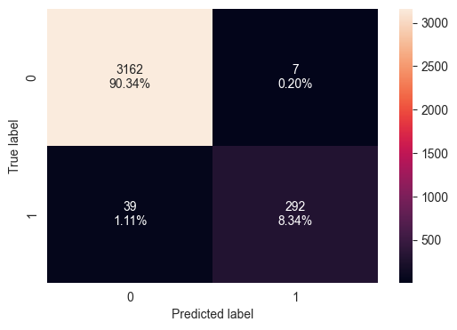

```python
# to create a confusion matrix for train set
confusion_matrix_sklearn(dTree_pre_pruned, X_train, y_train)
```

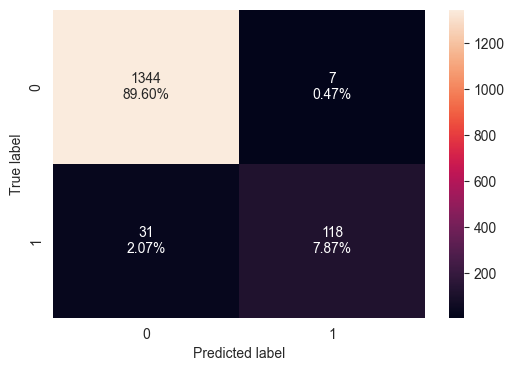

```python
# to create a confusion matrix for test set
confusion_matrix_sklearn(dTree_pre_pruned, X_test, y_test)
```

### Visualize the Decision Tree for Pre-Pruned Model

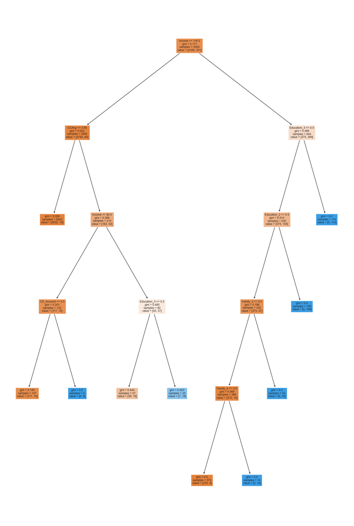

```python
# Now, let's visualize the tree
feature_names = list(X_train.columns)

plt.figure(figsize=(20, 30))
out = tree.plot_tree(dTree_pre_pruned, feature_names=feature_names, filled=True, fontsize=9, node_ids=False, class_names=None)

# below code will add arrows to the decision tree split if they are missing
for o in out:
    arrow = o.arrow_patch
    if arrow is not None:
        arrow.set_edgecolor("black")
        arrow.set_linewidth(1)
plt.show()
```

### Find Gini Importance for Pre-Pruned Model

```
                         Imp
Income              0.335478
Education_2         0.258373
Education_3         0.188599
Family_3            0.107563
Family_4            0.051352
CCAvg               0.043100
CD_Account          0.015535
ZIPCode_94          0.000000
Family_2            0.000000
ZIPCode_96          0.000000
ZIPCode_95          0.000000
Age                 0.000000
ZIPCode_93          0.000000
ZIPCode_91          0.000000
CreditCard          0.000000
Online              0.000000
Securities_Account  0.000000
Mortgage            0.000000
ZIPCode_92          0.000000
```

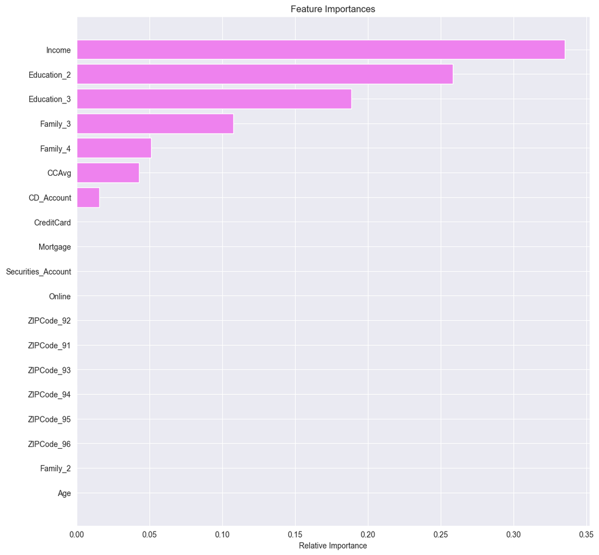

```python
# Gini Importance is the importance of a feature, which is normalized total reduction of the criterion brought by that feature.
print (pd.DataFrame(dTree_pre_pruned.feature_importances_, columns = ["Imp"],
                    index = X_train.columns).sort_values(by = 'Imp', ascending = False))

# Visualization of Gini importance for different features used in the model
importances = dTree_pre_pruned.feature_importances_
indices = np.argsort(importances)

plt.figure(figsize=(12,12))
plt.title('Feature Importances')
plt.barh(range(len(indices)), importances[indices], color='violet', align='center')
plt.yticks(range(len(indices)), [feature_names[i] for i in indices])
plt.xlabel('Relative Importance')
plt.show()
```

### Post-Pruning

#### Cost Complexity Pruning

- In DecisionTreeClassifier, Post pruning technique is parameterized by the cost complexity parameter, **ccp_alpha**.
  - Greater values of **ccp_alpha** increase the number of nodes pruned.

```python
clf = DecisionTreeClassifier(random_state=1, class_weight="balanced")
path = clf.cost_complexity_pruning_path(X_train, y_train)
ccp_alphas, impurities = abs(path.ccp_alphas), path.impurities

pd.DataFrame(path)
```

|  | ccp_alphas | impurities |
| --- | --- | --- |
| 0 | 0.000000e+00 | -6.161450e-15 |
| 1 | 3.853725e-19 | -6.161065e-15 |
| 2 | 3.853725e-19 | -6.160679e-15 |
| 3 | 3.853725e-19 | -6.160294e-15 |
| 4 | 3.853725e-19 | -6.159908e-15 |
| 5 | 5.255079e-19 | -6.159383e-15 |
| 6 | 5.255079e-19 | -6.158857e-15 |
| 7 | 5.255079e-19 | -6.158332e-15 |
| 8 | 7.006772e-19 | -6.157631e-15 |
| 9 | 7.707449e-19 | -6.156861e-15 |
| 10 | 7.707449e-19 | -6.156090e-15 |
| 11 | 7.882619e-19 | -6.155302e-15 |
| 12 | 1.257806e-17 | -6.142723e-15 |
| 13 | 3.250170e-16 | -5.817706e-15 |
| 14 | 1.566874e-04 | 3.133748e-04 |
| 15 | 1.569588e-04 | 6.272924e-04 |
| 16 | 2.857143e-04 | 9.130067e-04 |
| 17 | 2.998950e-04 | 1.212902e-03 |
| 18 | 3.020366e-04 | 2.119011e-03 |
| 19 | 3.036629e-04 | 3.030000e-03 |
| 20 | 3.049400e-04 | 3.334940e-03 |
| 21 | 3.106726e-04 | 3.645613e-03 |
| 22 | 3.127569e-04 | 4.583884e-03 |
| 23 | 4.574916e-04 | 5.498867e-03 |
| 24 | 4.663329e-04 | 6.897866e-03 |
| 25 | 5.220569e-04 | 7.419922e-03 |
| 26 | 5.621342e-04 | 7.982057e-03 |
| 27 | 5.893791e-04 | 8.571436e-03 |
| 28 | 5.900285e-04 | 9.161464e-03 |
| 29 | 6.098801e-04 | 9.771344e-03 |
| 30 | 6.292497e-04 | 1.102984e-02 |
| 31 | 7.538167e-04 | 1.178366e-02 |
| 32 | 7.539183e-04 | 1.253758e-02 |
| 33 | 7.592044e-04 | 1.481519e-02 |
| 34 | 9.269294e-04 | 1.574212e-02 |
| 35 | 9.347864e-04 | 1.854648e-02 |
| 36 | 9.511997e-04 | 1.949768e-02 |
| 37 | 1.233904e-03 | 2.073158e-02 |
| 38 | 1.981730e-03 | 2.469504e-02 |
| 39 | 2.150414e-03 | 2.684546e-02 |
| 40 | 2.375809e-03 | 2.922127e-02 |
| 41 | 2.987590e-03 | 3.220886e-02 |
| 42 | 3.302354e-03 | 3.551121e-02 |
| 43 | 3.344493e-03 | 3.885570e-02 |
| 44 | 3.602932e-03 | 4.606157e-02 |
| 45 | 3.729690e-03 | 4.979126e-02 |
| 46 | 4.754778e-03 | 5.930081e-02 |
| 47 | 5.713990e-03 | 7.072880e-02 |
| 48 | 2.255792e-02 | 9.328672e-02 |
| 49 | 2.783350e-02 | 2.046207e-01 |
| 50 | 2.953793e-01 | 5.000000e-01 |

#### Total Impurity vs Effective alpha for training set

- Minimal cost complexity pruning recursively finds the node with the *"weakest link"*.
  - The weakest link is characterized by an effective alpha, where the nodes with the smallest effective alpha are pruned first.
- To get an idea of what values of **ccp_alpha** could be appropriate, scikit-learn provides *DecisionTreeClassifier.cost_complexity_pruning_path* that returns the effective alphas and the corresponding total leaf impurities at each step of the pruning process.
  - As alpha increases, more of the tree is pruned, which increases the total impurity of its leaves.

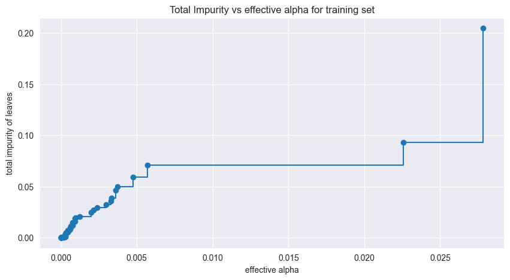

```python
fig, ax = plt.subplots(figsize=(10, 5))
ax.plot(ccp_alphas[:-1], impurities[:-1], marker="o", drawstyle="steps-post")
ax.set_xlabel("effective alpha")
ax.set_ylabel("total impurity of leaves")
ax.set_title("Total Impurity vs effective alpha for training set")
plt.show()
```

- Next, we train a decision tree using the effective alphas. The last value in ccp_alphas is the alpha value that prunes the whole tree, leaving the tree, clfs[-1], with one node.

```python
clfs = []
for ccp_alpha in ccp_alphas:
    clf = DecisionTreeClassifier(random_state=1, ccp_alpha=ccp_alpha, class_weight="balanced")
    clf.fit(X_train, y_train)
    clfs.append(clf)
print("Number of nodes in the last tree is: {} with ccp_alpha: {}".format(
      clfs[-1].tree_.node_count, ccp_alphas[-1]))
```

```
Number of nodes in the last tree is: 1 with ccp_alpha: 0.2953792759992323
```

#### Number of nodes & Depth vs alpha

- For the remainder, we remove the last element in clfs and ccp_alphas, because it is the trivial tree with only one node.
- Here we show that the number of nodes and tree depth decreases as alpha increases.

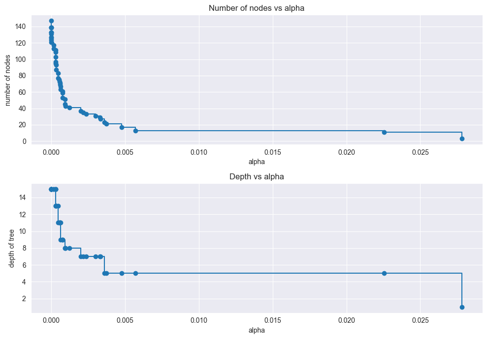

```python
clfs = clfs[:-1]
ccp_alphas = ccp_alphas[:-1]

node_counts = [clf.tree_.node_count for clf in clfs]
depth = [clf.tree_.max_depth for clf in clfs]
fig, ax = plt.subplots(2, 1,figsize=(10,7))
ax[0].plot(ccp_alphas, node_counts, marker='o', drawstyle="steps-post")
ax[0].set_xlabel("alpha")
ax[0].set_ylabel("number of nodes")
ax[0].set_title("Number of nodes vs alpha")
ax[1].plot(ccp_alphas, depth, marker='o', drawstyle="steps-post")
ax[1].set_xlabel("alpha")
ax[1].set_ylabel("depth of tree")
ax[1].set_title("Depth vs alpha")
fig.tight_layout()
```

#### Recall Train

```python
recall_train=[]
for clf in clfs:
    pred_train=clf.predict(X_train)
    values_train=metrics.recall_score(y_train,pred_train)
    recall_train.append(values_train)
```

#### Recall Test

```python
recall_test=[]
for clf in clfs:
    pred_test=clf.predict(X_test)
    values_test=metrics.recall_score(y_test,pred_test)
    recall_test.append(values_test)
```

#### Visualization

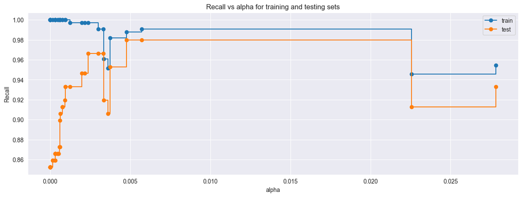

```python
fig, ax = plt.subplots(figsize=(15, 5))
ax.set_xlabel("alpha")
ax.set_ylabel("Recall")
ax.set_title("Recall vs alpha for training and testing sets")
ax.plot(
    ccp_alphas, recall_train, marker="o", label="train", drawstyle="steps-post",
)
ax.plot(ccp_alphas, recall_test, marker="o", label="test", drawstyle="steps-post")
ax.legend()
plt.show()
```

### Identify Best Post-Pruned Model

```python
# creating the model where we get highest train and test recall
index_best_model = np.argmax(recall_test)
dTree_post_pruned = clfs[index_best_model]
print(dTree_post_pruned)
```

```
DecisionTreeClassifier(ccp_alpha=0.004754778197299449, class_weight='balanced',
                       random_state=1)
```

### Score the Post-Pruned Model

```python
print("Accuracy on training set : ",dTree_post_pruned.score(X_train, y_train))
print("Accuracy on test set : ",dTree_post_pruned.score(X_test, y_test))
```

```
Accuracy on training set :  0.9391428571428572
Accuracy on test set :  0.938
```

### Check Post-Pruned Model Performance

#### On Train Set

```python
# to check the classification metrics on train set
dTree_post_pruned_perf_train = model_performance_classification(dTree_post_pruned, X_train, y_train)
dTree_post_pruned_perf_train
```

|  | Accuracy | Recall | Precision | F1 |
| --- | --- | --- | --- | --- |
| 0 | 0.939143 | 0.987915 | 0.610075 | 0.754325 |

#### On Test Set

```python
# to check the classification metrics on test set
dTree_post_pruned_perf_test = model_performance_classification(dTree_post_pruned, X_test, y_test)
dTree_post_pruned_perf_test
```

|  | Accuracy | Recall | Precision | F1 |
| --- | --- | --- | --- | --- |
| 0 | 0.938 | 0.979866 | 0.618644 | 0.758442 |

### Confusion Matrix for Post-Pruned Model

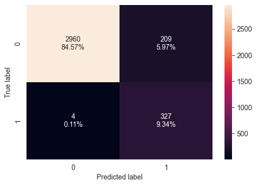

```python
# to create a confusion matrix for train set
confusion_matrix_sklearn(dTree_post_pruned, X_train, y_train)
```

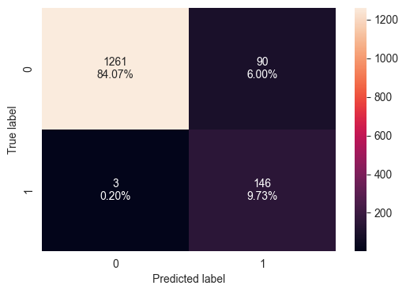

```python
# to create a confusion matrix for test set
confusion_matrix_sklearn(dTree_post_pruned, X_test, y_test)
```

### Visualize the Decision Tree for Post-Pruned Model

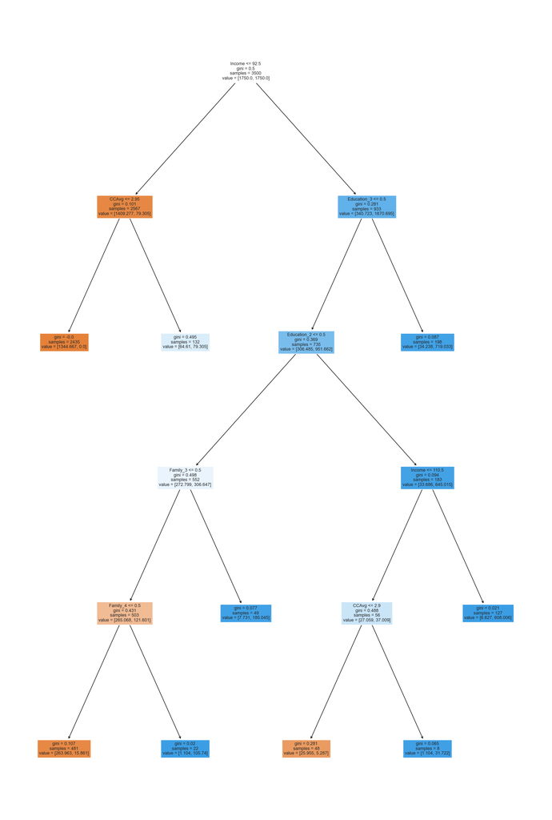

```python
# Now, let's visualize the tree
feature_names = list(X_train.columns)

plt.figure(figsize=(20, 30))
out = tree.plot_tree(dTree_post_pruned, feature_names=feature_names, filled=True, fontsize=9, node_ids=False, class_names=None)

# below code will add arrows to the decision tree split if they are missing
for o in out:
    arrow = o.arrow_patch
    if arrow is not None:
        arrow.set_edgecolor("black")
        arrow.set_linewidth(1)
plt.show()
```

### Find Gini Importance for Post-Pruned Model

```
                         Imp
Income              0.682995
Family_4            0.087270
Education_2         0.071891
Family_3            0.069482
CCAvg               0.064375
Education_3         0.023987
ZIPCode_94          0.000000
Family_2            0.000000
ZIPCode_96          0.000000
ZIPCode_95          0.000000
Age                 0.000000
ZIPCode_93          0.000000
ZIPCode_91          0.000000
CreditCard          0.000000
Online              0.000000
CD_Account          0.000000
Securities_Account  0.000000
Mortgage            0.000000
ZIPCode_92          0.000000
```

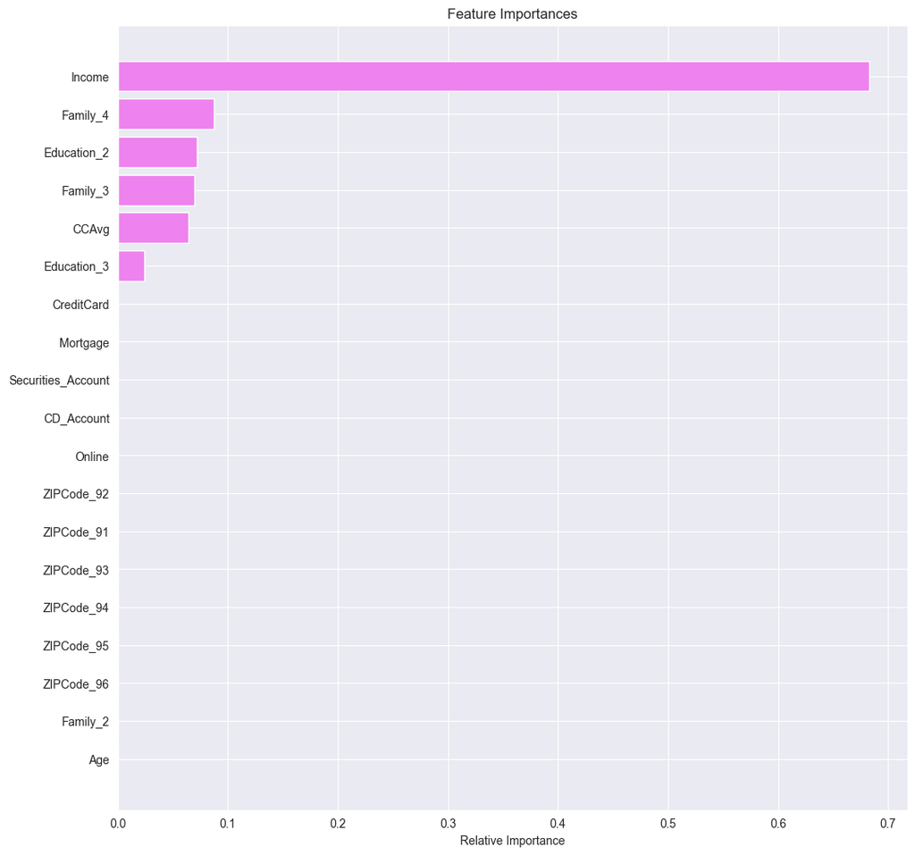

```python
# Gini Importance is the importance of a feature, which is normalized total reduction of the criterion brought by that feature.
print (pd.DataFrame(dTree_post_pruned.feature_importances_, columns = ["Imp"],
                    index = X_train.columns).sort_values(by = 'Imp', ascending = False))

# Visualization of Gini importance for different features used in the model
importances = dTree_post_pruned.feature_importances_
indices = np.argsort(importances)

plt.figure(figsize=(12,12))
plt.title('Feature Importances')
plt.barh(range(len(indices)), importances[indices], color='violet', align='center')
plt.yticks(range(len(indices)), [feature_names[i] for i in indices])
plt.xlabel('Relative Importance')
plt.show()
```

## Model Comparison and Final Model Selection

### Comparing Training Performance

```python
models_train_comp_df = pd.concat([dTree_perf_train.T, dTree_pre_pruned_perf_train.T, dTree_post_pruned_perf_train.T], axis=1)
models_train_comp_df.columns = ["Decision Tree (Default)", "Decision Tree (Pre-Pruning)", "Decision Tree (Post-Pruning)"]
print("Training performance comparison:")
models_train_comp_df
```

```
Training performance comparison:
```

|  | Decision Tree (Default) | Decision Tree (Pre-Pruning) | Decision Tree (Post-Pruning) |
| --- | --- | --- | --- |
| Accuracy | 1.0 | 0.986857 | 0.939143 |
| Recall | 1.0 | 0.882175 | 0.987915 |
| Precision | 1.0 | 0.976589 | 0.610075 |
| F1 | 1.0 | 0.926984 | 0.754325 |

### Comparing Testing Performance

```python
models_test_comp_df = pd.concat([dTree_perf_test.T, dTree_pre_pruned_perf_test.T, dTree_post_pruned_perf_test.T], axis=1)
models_test_comp_df.columns = ["Decision Tree (Default)", "Decision Tree (Pre-Pruning)", "Decision Tree (Post-Pruning)"]
print("Testing performance comparison:")
models_test_comp_df
```

```
Testing performance comparison:
```

|  | Decision Tree (Default) | Decision Tree (Pre-Pruning) | Decision Tree (Post-Pruning) |
| --- | --- | --- | --- |
| Accuracy | 0.980667 | 0.974667 | 0.938000 |
| Recall | 0.912752 | 0.791946 | 0.979866 |
| Precision | 0.894737 | 0.944000 | 0.618644 |
| F1 | 0.903654 | 0.861314 | 0.758442 |

## Actionable Insights and Business Recommendations

- **Use Case**: **Target Identification**
- **Business Objective**: *Bank wants to increase its revenue by growing their **asset customer** base, while retaining their **liability customer** base, by offering targeted & personalized Personal loans to prospective loan applicants among their liability customers, instead of bulk notifications being sent to all customers, which doesn't really attract customers.*
- In the context of Model predictions, there could be 2 types of errors:
  - **Type 1 Error**: **False Positive**:
    - So, the model predicted that customer will apply for Personal Loan -> Bank reached out to customer offering loan -> Customer Denied.
  - **Type 2 Error**: **False Negative:
    - So, the model predicted that the customer will not apply for Personal Loan -> Bank doesn't reach out a customer that would have purchased the loan
- In this case, the Bank would be more tolerant to **Type 1** errors for reaching out to the customer, but getting denied.
- However, **Type 2** errors are bad for business, as a prospective customer wouldn't be identified or reached, leading to *Opportunity loss*.
- The customers that falls within the **True Positive** area, are the sure-shot customers and should definitely be reached out to, as there is a very high conversion rate.
- It might be also beneficial for the bank to understand & investigate on what could motivate the large customer base falling under the **True Negative** area, that the model identifies as non-potential customers & it turns out to be true.
  - In case of these customers, the Bank might want to figure out a better offering, that better meets their need.
    - For e.g. it was observed that *customers under 26 yrs old haven't taken a Personal Loan from the last campaign*. However, at that age, the customers might be more motivated to purchase an Education loan or an Auto loan, offered at a competitive rate.
- Here, **Model Accuracy** wouldn't be great measure, as this is a classification problem. So, we need to select the model with the highest **Recall**, as we want to reduce the **Type 2** errors or **False Negatives**.
- Even if the **Precision** is lower, it is tolerable to the business as this represents the portion of customers that were predicted to be prospective customers by the model, but they denied the loan offerings. This is okay, as the loss to the bank is *only wasted effort* in converting the customer, but it still goes as a Customer Relationship Engagements, so no real loss here.
- Based on all these aspects, we can conclude that the **Post-Pruned Decision Tree** with the **highest recall of 0.979866** would be the best model to predict the prospective customer & offer tailored Personal loan to them.
  - We can see that the **Post-Pruned** tree seems to be *lowest in Precision score*. However, as already mentioned, this wouldn't really matter in the current Use-case.